# MCMC Simulation for Partial Order Inference

Bayesian Inference with Reversible Jump MCMC

BayesianPO Package

2025-05-27

# Introduction

This tutorial demonstrates the Metropolis-Hastings Markov Chain Monte Carlo (MH-MCMC) process applied to partial orders, implementing the methodology described in [Nicholls et al. (2024)](https://arxiv.org/abs/2212.05524) using the **BayesianPO** R package.

The tutorial covers two main implementations:

1. **Fixed Dimension MCMC**: Standard MCMC with fixed number of latent dimensions
2. **Reversible Jump MCMC**: Variable dimension sampling that automatically determines optimal K

## Key Features

- **Flexible Noise Models**: Support for queue-jump and Mallows noise
- **Covariate Integration**: Incorporation of external covariates
- **Reversible Jump MCMC**: Automatic dimension selection
- **Convergence Diagnostics**: Comprehensive monitoring tools

# Mathematical Background

## Partial Order Model

For α and Σ_ρ defined above, if we take:

$$U_{j,:} \sim N(0, \Sigma_\rho), \text{ independent for each } j \in M$$
$$\eta_{j,:} = G^{-1}(\Phi(U_{j,:})) + \alpha_j \mathbf{1}_K^T$$
$$y \sim p(\cdot|h(\eta(U, \beta)))$$

then $h(\eta_{:,k}) \sim PL(\alpha; M)$ for each $k = 1, \ldots, K$.

## Queue Jump Error Model

Before the $i$-th entry $(y_i)$ is chosen: - There are $m - i + 1$ elements remaining $(y_{i:m})$ - With probability $p$: $y_i$ is chosen randomly (ignoring order constraints) - With probability $(1-p)$: $y_i$ is the maximal element in a random linear extension

The probability of a sequence $y_{1:m}$ given poset $h$ and noise parameter $p$ is:

$$p_s(y_{1:m}|h, p) = \prod_{i=1}^{m-1} q(y_{i:m}|h[y_{i:m}], p)$$

where:

$$q(y_{i:m}|h[y_{i:m}], p) = \frac{p}{m-j+1} + (1-p)q_{y_{i:m}}(y_i|h[y_{i:m}])$$

## Reversible Jump MCMC for Dimension Selection

The reversible jump MCMC extends the standard algorithm by allowing the dimension $K$ to vary. The key moves are:

- **Birth move**: $K \rightarrow K+1$ by adding a new latent dimension
- **Death move**: $K \rightarrow K-1$ by removing a latent dimension

The acceptance probability includes: - Prior ratio: $\frac{p(K')}{p(K)}$ - Likelihood ratio: $\frac{p(y|K')}{p(y|K)}$ - Proposal ratio: $\frac{q(K|K')}{q(K'|K)}$ - Jacobian term for the transformation

# Setup and Installation

```r
# Load the BayesianPO package
source("../R/utilities.R")
source("../R/mcmc.R")
source("../R/mcmc_rj.R")  # Load reversible jump MCMC
source("../R/analysis.R")

library(mvtnorm)
library(ggplot2)
library(igraph)

# Set random seed for reproducibility
set.seed(42)
```

# Data Generation

## Generate Synthetic Partial Order

```r
# Model parameters
n <- 6  # Number of items
N <- 30  # Number of total orders to sample
K <- 3   # Number of latent dimensions
p <- 2   # Number of covariates

# Generate true parameters
rho_true <- 0.7
prob_noise_true <- 0.1
beta_true <- c(0.5, -0.3)

# Create design matrix (p x n, where p is number of covariates)
X <- matrix(rnorm(p * n), nrow = p, ncol = n)

# Generate synthetic data
synthetic_data <- generate_synthetic_data(
  n_items = n,
  n_observations = N,
  K = K,
  rho_true = rho_true,
  prob_noise_true = prob_noise_true,
  beta_true = beta_true,
  X = t(X),  # transpose to make it n x p for the function
  random_seed = 42
)

# Extract components
items <- synthetic_data$items
observed_orders <- synthetic_data$observed_orders
choice_sets <- synthetic_data$choice_sets
h_true <- synthetic_data$h_true

cat("Generated partial order with", sum(h_true), "direct relationships\n")
```

```
## Generated partial order with 7 direct relationships
```

```r
cat("Number of linear extensions:", count_linear_extensions(h_true), "\n")
```

[output not shown]

## Visualize the True Partial Order

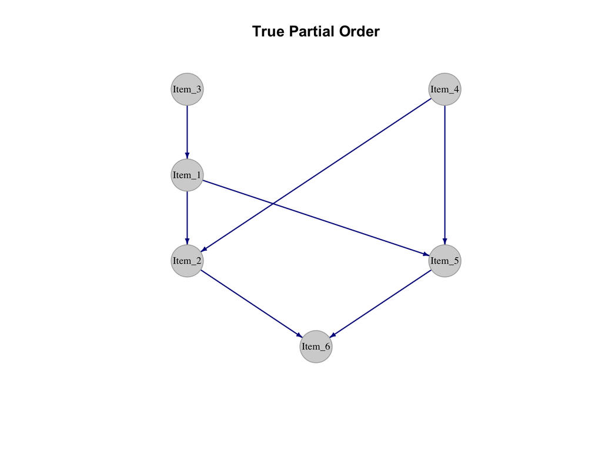

```r
# Create visualization of the true partial order with clean styling
plot_partial_order(h_true, items, title = "True Partial Order",
                  vertex_size = 25, edge_arrow_size = 0.4,
                  vertex_color = "lightgray",
                  vertex_frame_color = "darkgray",
                  edge_color = "darkblue")
```

# Standard MCMC Implementation

## Fixed Dimension MCMC

```r
# MCMC parameters
num_iterations <- 10000  # Reduced for faster demonstration
burn_in <- 200

# Update probabilities (must sum to 1)
mcmc_pt <- c(0.2, 0.2, 0.4, 0.2)  # rho, noise, U, beta

# Prior parameters
rho_prior <- 0.16667
noise_beta_prior <- 9.0
sigma_beta <- 1.0

# Run fixed dimension MCMC
mcmc_results <- mcmc_partial_order(
  observed_orders = observed_orders,
  choice_sets = choice_sets,
  num_iterations = num_iterations,
  K = K,
  X = X,
  dr = 0.1,                    # Multiplicative step for rho
  drbeta = 0.1,               # Step size for beta
  sigma_mallow = 0.1,         # Mallows parameter step
  sigma_beta = sigma_beta,
  noise_option = "queue_jump",
  mcmc_pt = mcmc_pt,
  rho_prior = rho_prior,
  noise_beta_prior = noise_beta_prior,
  mallow_ua = 10.0,
  random_seed = 42
)
```

[output not shown]

```r
cat("MCMC completed with acceptance rate:",
    round(mcmc_results$overall_acceptance_rate * 100, 2), "%\n")
```

```
## MCMC completed with acceptance rate: 45.46 %
```

# Reversible Jump MCMC Implementation

The reversible jump MCMC allows the number of latent dimensions K to vary during sampling, automatically determining the optimal model complexity.

```r
# Reversible Jump MCMC parameters
mcmc_pt_rj <- c(0.15, 0.15, 0.3, 0.15, 0.25)  # rho, noise, U, beta, K

# Prior for K (Poisson with rate K_prior)
K_prior <- 3.0

# Run Reversible Jump MCMC
rj_results <- mcmc_partial_order_k(
  observed_orders = observed_orders,
  choice_sets = choice_sets,
  num_iterations = num_iterations,
  X = X,
  dr = 0.1,
  drbeta = 0.1,
  sigma_mallow = 0.1,
  sigma_beta = sigma_beta,
  noise_option = "queue_jump",
  mcmc_pt = mcmc_pt_rj,
  rho_prior = rho_prior,
  noise_beta_prior = noise_beta_prior,
  mallow_ua = 10.0,
  K_prior = K_prior,
  random_seed = 42
)
```

```
## Iteration 1000/10000 - Accept Rate: 47.80%
## Iteration 2000/10000 - Accept Rate: 49.50%
## Iteration 3000/10000 - Accept Rate: 50.57%
## Iteration 4000/10000 - Accept Rate: 50.50%
## Iteration 5000/10000 - Accept Rate: 50.18%
## Iteration 6000/10000 - Accept Rate: 49.68%
## Iteration 7000/10000 - Accept Rate: 49.56%
## Iteration 8000/10000 - Accept Rate: 49.89%
## Iteration 9000/10000 - Accept Rate: 50.13%
## Iteration 10000/10000 - Accept Rate: 50.21%
##
## Overall Acceptance Rate after 10000 iterations: 50.21%
```

```r
cat("Reversible Jump MCMC completed with acceptance rate:",
    round(rj_results$overall_acceptance_rate * 100, 2), "%\n")
```

```
## Reversible Jump MCMC completed with acceptance rate: 50.21 %
```

# Results and Diagnostics

## Parameter Estimation Comparison

```r
# Extract posterior estimates (after burn-in)
burn_indices <- (burn_in/100 + 1):length(mcmc_results$rho_trace)
rj_burn_indices <- (burn_in/100 + 1):length(rj_results$rho_trace)

# Fixed dimension estimates
rho_est_fixed <- mean(mcmc_results$rho_trace[burn_indices])
beta_est_fixed <- colMeans(do.call(rbind, mcmc_results$beta_trace[burn_indices]))

# Reversible jump estimates
rho_est_rj <- mean(rj_results$rho_trace[rj_burn_indices])
beta_est_rj <- colMeans(do.call(rbind, rj_results$beta_trace[rj_burn_indices]))
K_est_rj <- round(mean(rj_results$K_trace[rj_burn_indices]))

# Create comparison table
comparison_df <- data.frame(
  Parameter = c("rho", "beta_1", "beta_2", "K"),
  True_Value = c(rho_true, beta_true, K),
  Fixed_MCMC = c(rho_est_fixed, beta_est_fixed, K),
  RJ_MCMC = c(rho_est_rj, beta_est_rj, K_est_rj)
)

print(comparison_df)
```

```
##   Parameter True_Value  Fixed_MCMC    RJ_MCMC
## 1       rho        0.7  0.16875810  0.0551155
## 2    beta_1        0.5  0.02167277 -0.7022100
## 3    beta_2       -0.3 -0.21188605  0.1139758
## 4         K        3.0  3.00000000  6.0000000
```

## Trace Plots

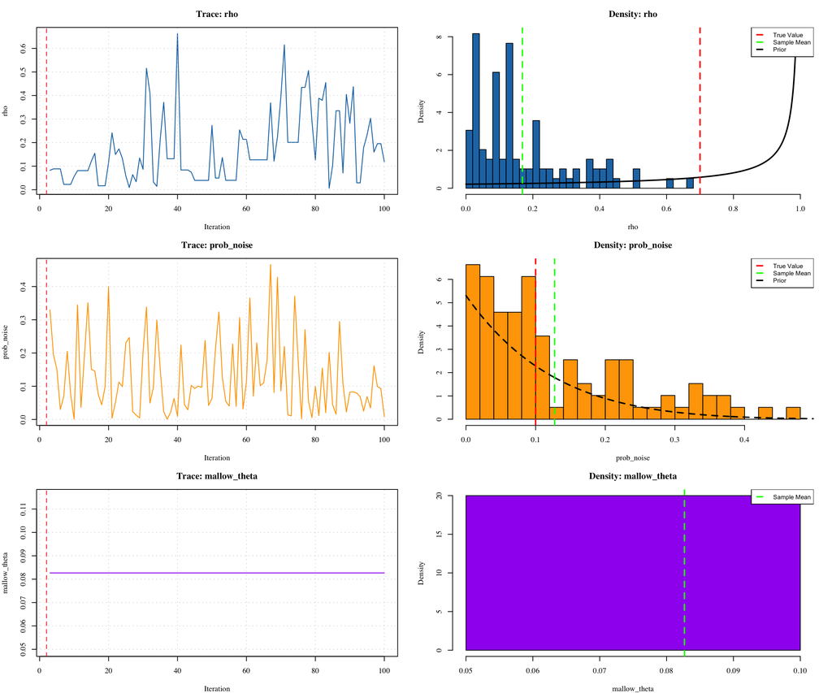

```r
# Create comprehensive trace plots with prior/posterior comparisons
true_params <- list(
  rho_true = rho_true,
  prob_noise_true = prob_noise_true
)

config <- list(
  prior = list(
    rho_prior = rho_prior,
    noise_beta_prior = noise_beta_prior
  ),
  noise = list(
    noise_option = "queue_jump"
  )
)

plot_mcmc_results(mcmc_results,
                 true_param = true_params,
                 config = config,
                 burn_in = 2)
```

## RJ-MCMC Trace Plots

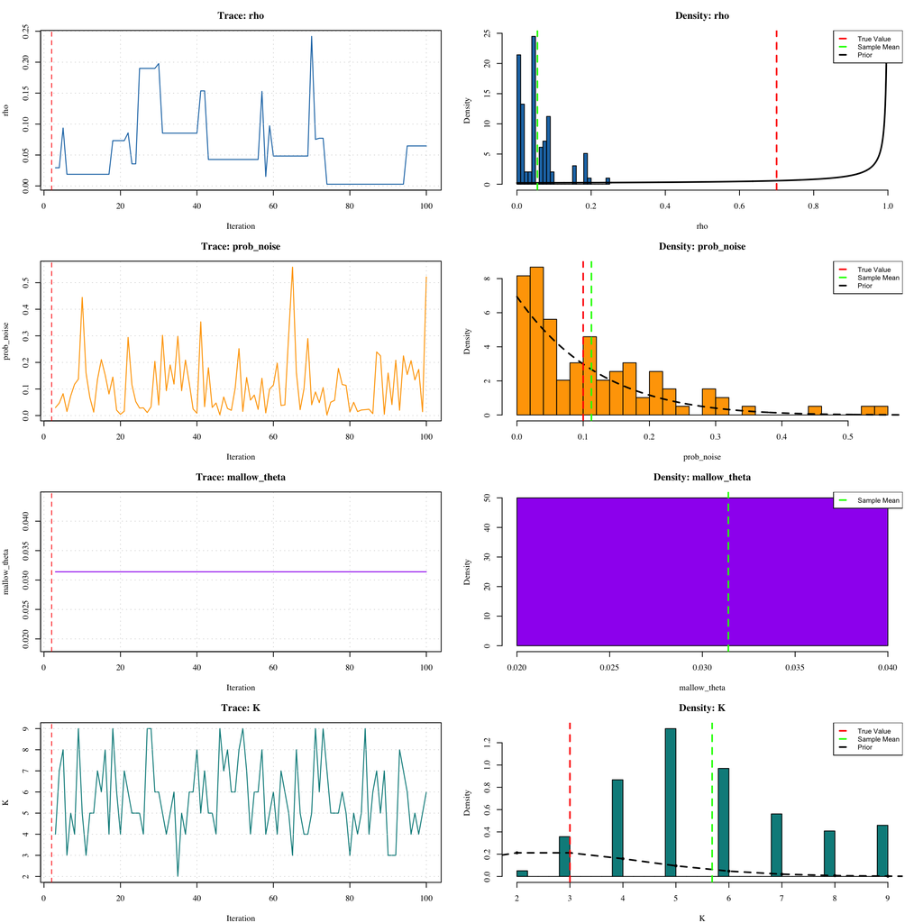

```r
# Create comprehensive trace plots for RJ-MCMC with K dimension
rj_config <- list(
  prior = list(
    rho_prior = rho_prior,
    noise_beta_prior = noise_beta_prior,
    K_prior = K_prior
  ),
  noise = list(
    noise_option = "queue_jump"
  )
)

rj_true_params <- list(
  rho_true = rho_true,
  prob_noise_true = prob_noise_true,
  K_true = K
)

plot_mcmc_results(rj_results,
                 true_param = rj_true_params,
                 config = rj_config,
                 burn_in = 2)
```

## Dimension Selection Analysis

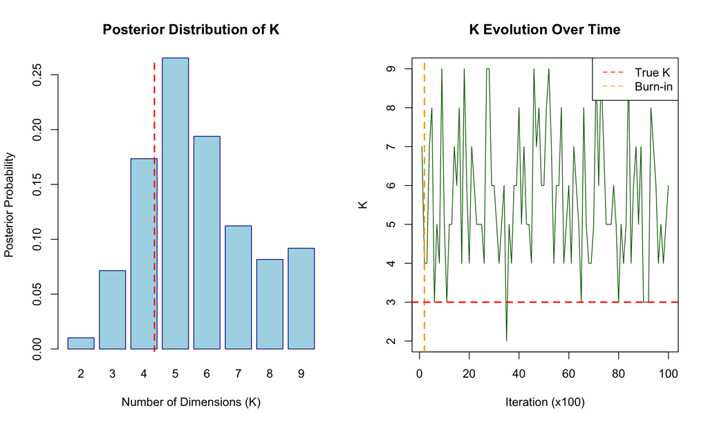

```r
# Analyze K posterior distribution
K_posterior <- table(rj_results$K_trace[rj_burn_indices])
K_probs <- K_posterior / sum(K_posterior)

# Plot K posterior
par(mfrow = c(1, 2))

barplot(K_probs, main = "Posterior Distribution of K",
        xlab = "Number of Dimensions (K)", ylab = "Posterior Probability",
        col = "lightblue", border = "darkblue")
abline(v = K + 0.5, col = "red", lty = 2, lwd = 2)

# Plot K trace with burn-in
plot(rj_results$K_trace, type = "l", main = "K Evolution Over Time",
     xlab = "Iteration (x100)", ylab = "K", col = "darkgreen")
abline(v = burn_in/100, col = "orange", lty = 2, lwd = 2)
abline(h = K, col = "red", lty = 2, lwd = 2)
legend("topright", c("True K", "Burn-in"), col = c("red", "orange"), lty = 2)
```

```r
par(mfrow = c(1, 1))

cat("Posterior mode for K:", names(K_probs)[which.max(K_probs)], "\n")
```

```
## Posterior mode for K: 5
```

```r
cat("Posterior mean for K:", round(mean(rj_results$K_trace[rj_burn_indices]), 2), "\n")
```

```
## Posterior mean for K: 5.68
```

## Convergence Diagnostics

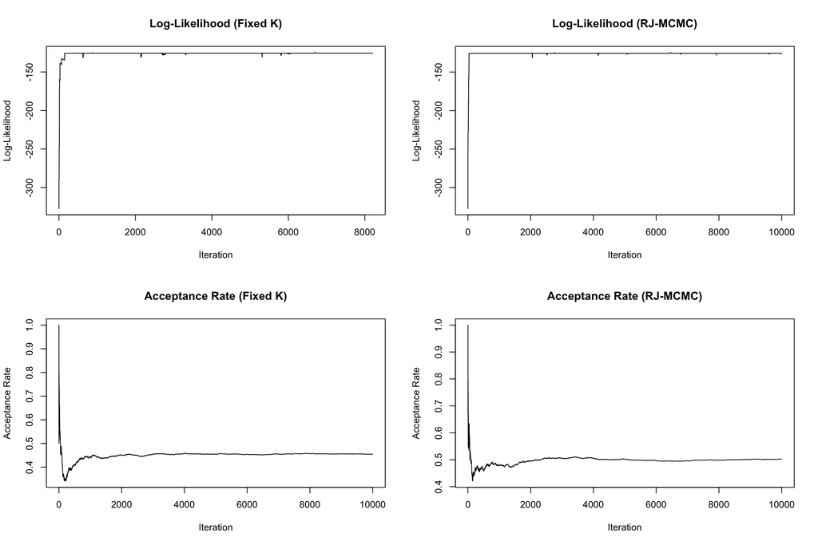

```r
# Plot log-likelihood traces
par(mfrow = c(2, 2))

# Check if we have valid data before plotting
if (length(mcmc_results$log_likelihood_currents) > 0 &&
    all(is.finite(mcmc_results$log_likelihood_currents))) {
  plot(mcmc_results$log_likelihood_currents, type = "l",
       main = "Log-Likelihood (Fixed K)", xlab = "Iteration", ylab = "Log-Likelihood")
} else {
  plot(1, type = "n", main = "Log-Likelihood (Fixed K) - No Valid Data",
       xlab = "Iteration", ylab = "Log-Likelihood")
}

if (length(rj_results$log_likelihood_currents) > 0 &&
    all(is.finite(rj_results$log_likelihood_currents))) {
  plot(rj_results$log_likelihood_currents, type = "l",
       main = "Log-Likelihood (RJ-MCMC)", xlab = "Iteration", ylab = "Log-Likelihood")
} else {
  plot(1, type = "n", main = "Log-Likelihood (RJ-MCMC) - No Valid Data",
       xlab = "Iteration", ylab = "Log-Likelihood")
}

# Acceptance rates over time
if (length(mcmc_results$acceptance_rates) > 0 &&
    all(is.finite(mcmc_results$acceptance_rates))) {
  plot(mcmc_results$acceptance_rates, type = "l",
       main = "Acceptance Rate (Fixed K)", xlab = "Iteration", ylab = "Acceptance Rate")
} else {
  plot(1, type = "n", main = "Acceptance Rate (Fixed K) - No Valid Data",
       xlab = "Iteration", ylab = "Acceptance Rate")
}

if (length(rj_results$acceptance_rates) > 0 &&
    all(is.finite(rj_results$acceptance_rates))) {
  plot(rj_results$acceptance_rates, type = "l",
       main = "Acceptance Rate (RJ-MCMC)", xlab = "Iteration", ylab = "Acceptance Rate")
} else {
  plot(1, type = "n", main = "Acceptance Rate (RJ-MCMC) - No Valid Data",
       xlab = "Iteration", ylab = "Acceptance Rate")
}
```

```r
par(mfrow = c(1, 1))
```

## Update Category Analysis (RJ-MCMC)

```
## [1] "Update Category Summary:"
##   category accepted.count accepted.accepted accepted.rate
## 1     beta     14.0000000         0.0000000     0.0000000
## 2        K     30.0000000        13.0000000     0.4333333
## 3    noise      9.0000000         9.0000000     1.0000000
## 4      rho     18.0000000         4.0000000     0.2222222
## 5        U     29.0000000         7.0000000     0.2413793
```

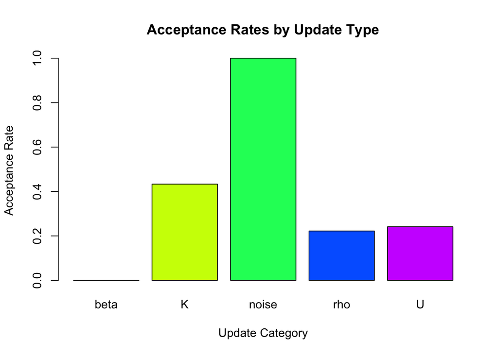

```r
# Analyze update categories and their acceptance rates
if ("update_df" %in% names(rj_results)) {
  update_summary <- aggregate(accepted ~ category, data = rj_results$update_df,
                             FUN = function(x) c(count = length(x),
                                                accepted = sum(x),
                                                rate = mean(x)))

  print("Update Category Summary:")
  print(update_summary)

  # Plot update acceptance rates by category
  category_rates <- aggregate(accepted ~ category, data = rj_results$update_df, mean)

  barplot(category_rates$accepted, names.arg = category_rates$category,
          main = "Acceptance Rates by Update Type",
          ylab = "Acceptance Rate", xlab = "Update Category",
          col = rainbow(nrow(category_rates)))
}
```

# Model Comparison and Validation

## Posterior Predictive Checks

```r
# Calculate burn-in index (convert to trace index)
burn_in_index <- burn_in / 100  # Since we store every 100 iterations
threshold <- 0.5

# Extract post-burn-in partial order traces
h_trace_fixed_post_burnin <- mcmc_results$h_trace[(burn_in_index + 1):length(mcmc_results$h_trace)]
h_trace_rj_post_burnin <- rj_results$h_trace[(burn_in_index + 1):length(rj_results$h_trace)]

# Compute posterior mean partial orders
cat("Computing posterior mean partial orders...\n")
```

```
## Computing posterior mean partial orders...
```

```r
# Fixed K MCMC: Average across all post-burn-in iterations
if (length(h_trace_fixed_post_burnin) > 0) {
  # Convert list of matrices to 3D array for easier averaging
  h_array_fixed <- array(0, dim = c(nrow(h_trace_fixed_post_burnin[[1]]),
                                   ncol(h_trace_fixed_post_burnin[[1]]),
                                   length(h_trace_fixed_post_burnin)))

  for (i in seq_along(h_trace_fixed_post_burnin)) {
    h_array_fixed[,,i] <- h_trace_fixed_post_burnin[[i]]
  }

  # Compute mean and apply threshold
  mean_h_fixed <- apply(h_array_fixed, c(1,2), mean)
  final_h_fixed <- (mean_h_fixed >= threshold) * 1

  # Apply transitive reduction to get minimal representation
  final_h_fixed <- transitive_reduction(final_h_fixed)

  cat("Fixed K MCMC: Averaged", length(h_trace_fixed_post_burnin), "post-burn-in samples\n")
} else {
  final_h_fixed <- matrix(0, nrow = nrow(h_true), ncol = ncol(h_true))
  cat("Warning: No post-burn-in samples for Fixed K MCMC\n")
}
```

```
## Fixed K MCMC: Averaged 98 post-burn-in samples
```

```r
# RJ-MCMC: Average across all post-burn-in iterations
if (length(h_trace_rj_post_burnin) > 0) {
  # Convert list of matrices to 3D array for easier averaging
  h_array_rj <- array(0, dim = c(nrow(h_trace_rj_post_burnin[[1]]),
                                ncol(h_trace_rj_post_burnin[[1]]),
                                length(h_trace_rj_post_burnin)))

  for (i in seq_along(h_trace_rj_post_burnin)) {
    h_array_rj[,,i] <- h_trace_rj_post_burnin[[i]]
  }

  # Compute mean and apply threshold
  mean_h_rj <- apply(h_array_rj, c(1,2), mean)
  final_h_rj <- (mean_h_rj >= threshold) * 1

  # Apply transitive reduction to get minimal representation
  final_h_rj <- transitive_reduction(final_h_rj)

  cat("RJ-MCMC: Averaged", length(h_trace_rj_post_burnin), "post-burn-in samples\n")
} else {
  final_h_rj <- matrix(0, nrow = nrow(h_true), ncol = ncol(h_true))
  cat("Warning: No post-burn-in samples for RJ-MCMC\n")
}
```

```
## RJ-MCMC: Averaged 98 post-burn-in samples
```

```r
# Compare with true partial order
accuracy_fixed <- sum(final_h_fixed == h_true) / length(h_true)
accuracy_rj <- sum(final_h_rj == h_true) / length(h_true)

cat("\nPartial Order Accuracy (using posterior mean with threshold", threshold, "):\n")
```

```
##
## Partial Order Accuracy (using posterior mean with threshold 0.5 ):
```

```r
cat("Fixed K MCMC:", round(accuracy_fixed * 100, 1), "%\n")
```

```
## Fixed K MCMC: 80.6 %
```

```r
cat("RJ-MCMC:", round(accuracy_rj * 100, 1), "%\n")
```

```
## RJ-MCMC: 80.6 %
```

```r
# Hamming distance
hamming_fixed <- sum(final_h_fixed != h_true)
hamming_rj <- sum(final_h_rj != h_true)

cat("\nHamming Distance from True Partial Order:\n")
```

```
##
## Hamming Distance from True Partial Order:
```

```r
cat("Fixed K MCMC:", hamming_fixed, "\n")
```

```
## Fixed K MCMC: 7
```

```r
cat("RJ-MCMC:", hamming_rj, "\n")
```

```
## RJ-MCMC: 7
```

```r
# Report number of edges in each estimate
cat("\nNumber of edges:\n")
```

```
##
## Number of edges:
```

```r
cat("True partial order:", sum(h_true), "edges\n")
```

```
## True partial order: 7 edges
```

```r
cat("Fixed K MCMC estimate:", sum(final_h_fixed), "edges\n")
```

```
## Fixed K MCMC estimate: 0 edges
```

```r
cat("RJ-MCMC estimate:", sum(final_h_rj), "edges\n")
```

```
## RJ-MCMC estimate: 0 edges
```

## Visualize Estimated Partial Orders

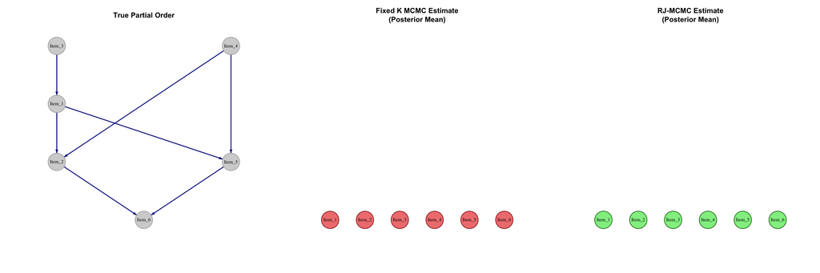

```r
par(mfrow = c(1, 3))

# True partial order
plot_partial_order(h_true, items, title = "True Partial Order",
                  vertex_size = 20, edge_arrow_size = 0.3,
                  vertex_color = "lightgray",
                  vertex_frame_color = "darkgray",
                  edge_color = "darkblue")

# Fixed K estimate (using posterior mean)
plot_partial_order(final_h_fixed, items, title = "Fixed K MCMC Estimate\n(Posterior Mean)",
                  vertex_size = 20, edge_arrow_size = 0.3,
                  vertex_color = "lightcoral",
                  vertex_frame_color = "darkred",
                  edge_color = "darkred")

# RJ-MCMC estimate (using posterior mean)
plot_partial_order(final_h_rj, items, title = "RJ-MCMC Estimate\n(Posterior Mean)",
                  vertex_size = 20, edge_arrow_size = 0.3,
                  vertex_color = "lightgreen",
                  vertex_frame_color = "darkgreen",
                  edge_color = "darkgreen")
```

```r
par(mfrow = c(1, 1))
```

## Posterior Uncertainty Analysis

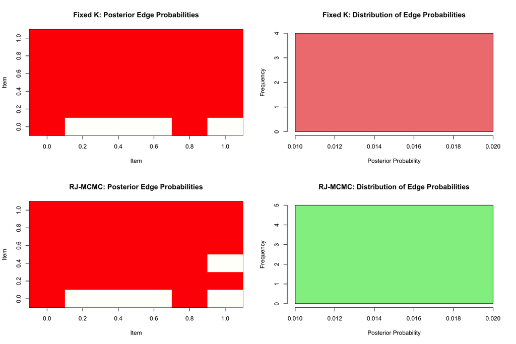

```
##
## Edges with posterior probability between 0.2 and 0.8 (high uncertainty):
## Fixed K: No highly uncertain edges found
## RJ-MCMC: No highly uncertain edges found
```

```r
# Analyze posterior uncertainty in partial order relationships
if (length(h_trace_fixed_post_burnin) > 0) {
  # Compute posterior probabilities for each edge
  posterior_probs_fixed <- apply(h_array_fixed, c(1,2), mean)

  # Create heatmap of posterior probabilities
  par(mfrow = c(2, 2))

  # Fixed K posterior probabilities
  image(posterior_probs_fixed, main = "Fixed K: Posterior Edge Probabilities",
        xlab = "Item", ylab = "Item", col = heat.colors(100))

  # Histogram of posterior probabilities (only if we have positive probabilities)
  positive_probs_fixed <- posterior_probs_fixed[posterior_probs_fixed > 0]
  if (length(positive_probs_fixed) > 0) {
    hist(positive_probs_fixed,
         main = "Fixed K: Distribution of Edge Probabilities",
         xlab = "Posterior Probability", ylab = "Frequency",
         breaks = 20, col = "lightcoral")
    abline(v = threshold, col = "red", lty = 2, lwd = 2)
  } else {
    plot(1, type = "n", main = "Fixed K: No Positive Edge Probabilities",
         xlab = "Posterior Probability", ylab = "Frequency")
    text(1, 1, "No edges with positive probability", cex = 1.2)
  }

  if (length(h_trace_rj_post_burnin) > 0) {
    # RJ-MCMC posterior probabilities
    posterior_probs_rj <- apply(h_array_rj, c(1,2), mean)

    image(posterior_probs_rj, main = "RJ-MCMC: Posterior Edge Probabilities",
          xlab = "Item", ylab = "Item", col = heat.colors(100))

    # Histogram of posterior probabilities (only if we have positive probabilities)
    positive_probs_rj <- posterior_probs_rj[posterior_probs_rj > 0]
    if (length(positive_probs_rj) > 0) {
      hist(positive_probs_rj,
           main = "RJ-MCMC: Distribution of Edge Probabilities",
           xlab = "Posterior Probability", ylab = "Frequency",
           breaks = 20, col = "lightgreen")
      abline(v = threshold, col = "red", lty = 2, lwd = 2)
    } else {
      plot(1, type = "n", main = "RJ-MCMC: No Positive Edge Probabilities",
           xlab = "Posterior Probability", ylab = "Frequency")
      text(1, 1, "No edges with positive probability", cex = 1.2)
    }
  } else {
    # Placeholder plots if no RJ-MCMC data
    plot(1, type = "n", main = "RJ-MCMC: No Data Available",
         xlab = "Item", ylab = "Item")
    plot(1, type = "n", main = "RJ-MCMC: No Data Available",
         xlab = "Posterior Probability", ylab = "Frequency")
  }

  par(mfrow = c(1, 1))

  # Report edges with high uncertainty
  cat("\nEdges with posterior probability between 0.2 and 0.8 (high uncertainty):\n")
  uncertain_edges_fixed <- which(posterior_probs_fixed > 0.2 & posterior_probs_fixed < 0.8, arr.ind = TRUE)
  if (nrow(uncertain_edges_fixed) > 0) {
    for (i in 1:nrow(uncertain_edges_fixed)) {
      row <- uncertain_edges_fixed[i, 1]
      col <- uncertain_edges_fixed[i, 2]
      prob <- posterior_probs_fixed[row, col]
      cat(sprintf("Fixed K: %s -> %s: %.3f\n", items[row], items[col], prob))
    }
  } else {
    cat("Fixed K: No highly uncertain edges found\n")
  }

  if (length(h_trace_rj_post_burnin) > 0) {
    uncertain_edges_rj <- which(posterior_probs_rj > 0.2 & posterior_probs_rj < 0.8, arr.ind = TRUE)
    if (nrow(uncertain_edges_rj) > 0) {
      for (i in 1:nrow(uncertain_edges_rj)) {
        row <- uncertain_edges_rj[i, 1]
        col <- uncertain_edges_rj[i, 2]
        prob <- posterior_probs_rj[row, col]
        cat(sprintf("RJ-MCMC: %s -> %s: %.3f\n", items[row], items[col], prob))
      }
    } else {
      cat("RJ-MCMC: No highly uncertain edges found\n")
    }
  }
} else {
  cat("No post-burn-in samples available for uncertainty analysis\n")
}
```

# Advanced Features

## MCMC Implementation Details

The `mcmc_partial_order_k` function implements the following update steps:

1. **Rho Update**: Multiplicative random walk with step size `dr`
2. **Noise Parameter Update**:
   - Queue-jump: Beta proposal
   - Mallows: Log-normal random walk
3. **Latent Matrix Update**: Single row updates with multivariate normal proposals
4. **Beta Update**: Component-wise normal random walk
5. **Dimension Update**: Birth/death moves for K

```r
# Example of manual parameter tuning
tuned_mcmc_pt <- c(0.1, 0.1, 0.4, 0.2, 0.2)  # Reduce K update frequency

# Run with different tuning
tuned_results <- mcmc_partial_order_k(
  observed_orders = observed_orders,
  choice_sets = choice_sets,
  num_iterations = 5000,  # Shorter run for demonstration
  X = X,
  dr = 1.05,              # Smaller step for rho
  drbeta = 0.05,          # Smaller step for beta
  sigma_mallow = 0.05,    # Smaller step for Mallows
  sigma_beta = sigma_beta,
  noise_option = "queue_jump",
  mcmc_pt = tuned_mcmc_pt,
  rho_prior = rho_prior,
  noise_beta_prior = noise_beta_prior,
  mallow_ua = 1.0,
  K_prior = K_prior,
  random_seed = 123
)
```

```
## Iteration 500/5000 - Accept Rate: 53.00%
## Iteration 1000/5000 - Accept Rate: 53.30%
## Iteration 1500/5000 - Accept Rate: 54.53%
## Iteration 2000/5000 - Accept Rate: 55.15%
## Iteration 2500/5000 - Accept Rate: 54.32%
## Iteration 3000/5000 - Accept Rate: 54.40%
## Iteration 3500/5000 - Accept Rate: 54.26%
## Iteration 4000/5000 - Accept Rate: 54.15%
## Iteration 4500/5000 - Accept Rate: 54.07%
## Iteration 5000/5000 - Accept Rate: 54.12%
##
## Overall Acceptance Rate after 5000 iterations: 54.12%
```

```r
cat("Tuned MCMC acceptance rate:",
    round(tuned_results$overall_acceptance_rate * 100, 2), "%\n")
```

```
## Tuned MCMC acceptance rate: 54.12 %
```

## Mallows Noise Model

```r
# Example with Mallows noise model
mallows_results <- mcmc_partial_order_k(
  observed_orders = observed_orders,
  choice_sets = choice_sets,
  num_iterations = 5000,
  X = X,
  dr = 1.1,
  drbeta = 0.1,
  sigma_mallow = 0.1,
  sigma_beta = sigma_beta,
  noise_option = "mallows_noise",  # Switch to Mallows
  mcmc_pt = mcmc_pt_rj,
  rho_prior = rho_prior,
  noise_beta_prior = noise_beta_prior,
  mallow_ua = 1.0,
  K_prior = K_prior,
  random_seed = 42
)
```

```
## Iteration 500/5000 - Accept Rate: 61.20%
## Iteration 1000/5000 - Accept Rate: 62.80%
## Iteration 1500/5000 - Accept Rate: 60.93%
## Iteration 2000/5000 - Accept Rate: 61.40%
## Iteration 2500/5000 - Accept Rate: 63.12%
## Iteration 3000/5000 - Accept Rate: 62.77%
## Iteration 3500/5000 - Accept Rate: 62.40%
## Iteration 4000/5000 - Accept Rate: 62.80%
## Iteration 4500/5000 - Accept Rate: 63.44%
## Iteration 5000/5000 - Accept Rate: 63.88%
##
## Overall Acceptance Rate after 5000 iterations: 63.88%
```

```r
cat("Mallows MCMC acceptance rate:",
    round(mallows_results$overall_acceptance_rate * 100, 2), "%\n")
```

```
## Mallows MCMC acceptance rate: 63.88 %
```

# Conclusion

This tutorial demonstrates the complete workflow for Bayesian partial order inference using the BayesianPO R package:

## Advantages of Reversible Jump MCMC

- **Automatic Model Selection**: No need to pre-specify the number of dimensions
- **Uncertainty Quantification**: Provides posterior distribution over model complexity
- **Robust Inference**: Less sensitive to initial parameter choices
- **Principled Comparison**: Enables formal model comparison via marginal likelihoods

## Best Practices

1. **Tuning**: Adjust step sizes to achieve 20-50% acceptance rates
2. **Burn-in**: Use sufficient burn-in period (typically 10-20% of total iterations)
3. **Convergence**: Monitor trace plots and acceptance rates
4. **Multiple Chains**: Run multiple chains to assess convergence

## Extensions and Applications

The methodology can be extended to:

- **Hierarchical Models**: Multi-level partial order structures
- **Time-Varying Orders**: Dynamic partial order evolution
- **Missing Data**: Handling incomplete observations
- **Large-Scale Problems**: Scalable algorithms for big data

## References

- Nicholls, G. K., et al. (2024). Bayesian inference for partial orders. *arXiv preprint arXiv:2212.05524*.
- Green, P. J. (1995). Reversible jump Markov chain Monte Carlo computation and Bayesian model determination. *Biometrika*, 82(4), 711-732.

*This tutorial was generated using the BayesianPO R package. For more information, see the package documentation and vignettes.*